# String Parsing - Aho-Corasick

**[Aho-Corasick Algorithm] – O(N+m1+m2+…+mk)**

**::Reference :** https://m.blog.naver.com/kks227/220992598966

- this algorithm is an unique one to many pattern matching algorithm.

- it looks like Trie structure, but it has failure function.

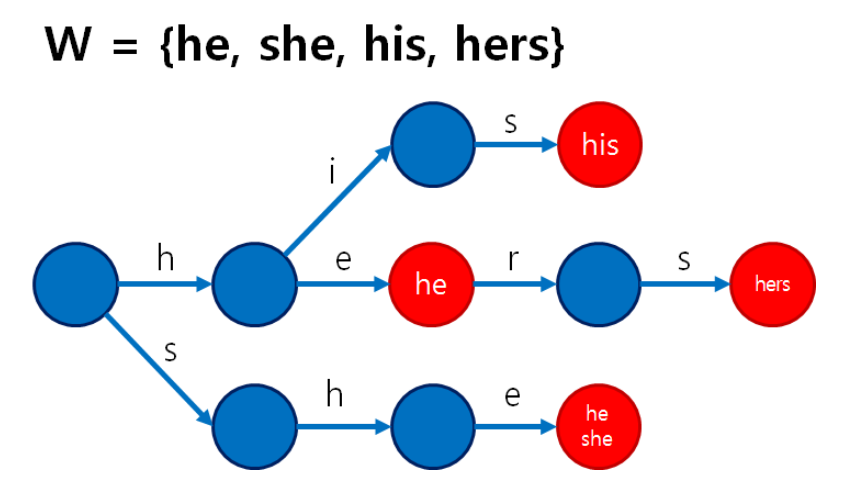

- the red nodes are output nodes. if we reach a red node, the strings which are in the red nodes appear in base string S.

- Function GO : Move to next state(ndoe)

- Function Output : rednodes have function output that returns string the node has.

- Function Failure : if we don’t have any further edge to go, we use Function Failure to go back a ertain state.

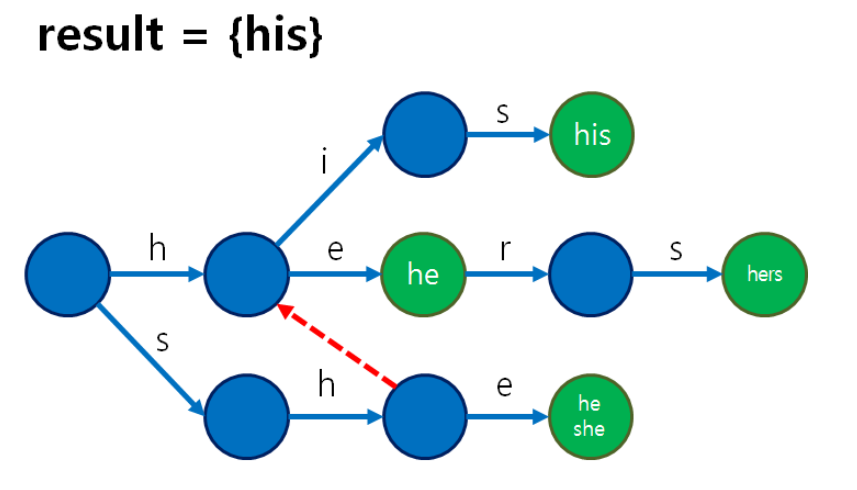

- Let’s follow the below picture.

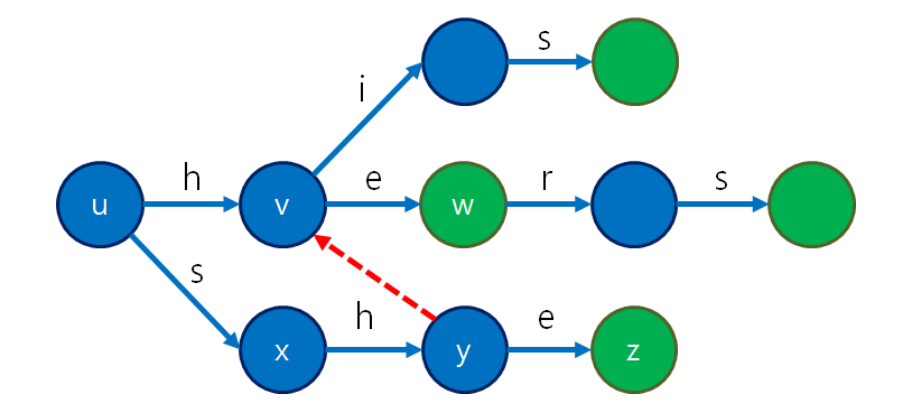

- then we can get such transitions.

> **go(u,h)=v , go(v,e)=w, go(u,s)=x, output(v)={}, output(w)={“he”}, failure(v)=u, failure(y)=v,** etc.

- Then, why is failure(y)=v?

> To get y, we have to pass s,h. To normalize it, I can say recent read string have to be s,h.

> To get v, we have to pass just h.

>> This algorithm is **one-to-many pattern matching** algorithm. Let’s assumne that we have two string h(…), sh(…) in the string set W. In this case, if the (…) string are same and if we find a string sh(…), then there must be a string h(…).

>> **So if we can’t go further on path sh(…), we don’t have anything to lose even if we change our path to h(…)’s.**

>> For instance using above picture, let’s S=”shis”, then we can arrive y, but after that we can’t go further. So we have to follow the red-dot line to go back to path h(…). Then we can find “his”.

>> **there is one more rule that Function Failure always points a more shallow node.**

- Let’s take another example.

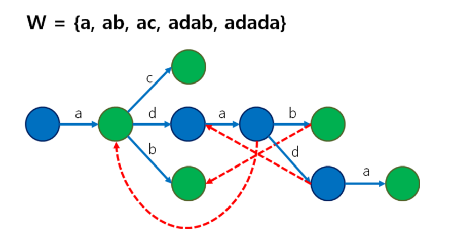

> if we arrive “ada”, then failure function leads us to first green node. Since both nodes recently red same character “a”.

> So, if we arrive “adad”, failure function leads us to second blue node. Since they recently red same string “ad”.

> In this case, nodes don’t have red-dot line have failure function that leads us to the root node.

**> if we can go back several nodes, then we must choose a node that has the longest same suffix.**

**- Total algorithm is below : Let’s assume that a current state is x and input is c.**

**> 1. if go(x,c) exists, go to a next state.**

**> 2. if go(x,c) doesn’t exist, go back to failure(x).**

**>> if we are on root after “2.”, stop. else return to “1.”**

**-** We can determine Failure function using BFS and DP.

**> if there is a string p, and we append x to p, then fail(px) = go(fail(p),x)**

**> In addition, we have to check, when fail(x)=y, output(x) include output(y).**

**- The Time complexity is O(length of S) + O(total length of words).**

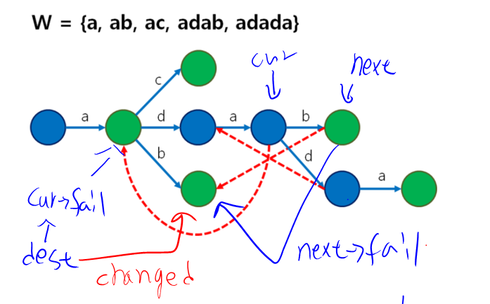

**- see the whole code.**

```cpp
#include<iostream>
#include<queue>
#include<algorithm>

using namespace std;

class Trie {
public:
	vector<Trie*> go; // let's assume that there are only lower case letters.
	Trie* fail; //this is failure function.

	bool output;

	Trie() {
		go.assign(26, nullptr);
		output = false;
	}
	~Trie() {
		for (int i = 0; i < 26; i++) if (go[i]) delete go[i];
	}

	void insert(const char *key) {
		if (*key == '\0') { //when we meet end of string
			output = true;
			return;
		}
		int next = *key - 'a'; //next character's index
		if (!go[next]) { // if we don't have such node
			go[next] = new Trie; //create it
		}
		go[next]->insert(key + 1);
	}

};

int main() {
	ios_base::sync_with_stdio(false);
	cin.tie(NULL); cout.tie(NULL);

	int N, M;
	string words;
	Trie* root = new Trie;
	cin >> N; //number of string
	for (int i = 0; i < N; i++) {
		cin >> words;
		root->insert(words.c_str); // to use pointer, we have to convert c++ string to c style string.
	}

	//Making Failure function
	queue<Trie*> que;
	root->fail = root;
	que.push(root);
	while (!que.empty()) {
		Trie* cur = que.front();
		que.pop();

		for (int i = 0; i < 26; i++) {
			Trie* next = cur->go[i];
			if (!next) continue; //when next node doesn't exist

			if (cur == root) next->fail = root;
			else {
				Trie* dest = cur->fail;
				// finding a closest ancient to reference failure function.
				while (dest != root && !dest->go[i])
					dest = dest->fail;

				// failure(px) = go(failure(p),x)
				if (dest->go[i]) dest = dest->go[i];
				next->fail = dest;
			}
			// when failure(x)=y, check output(x) include output(y)
			if (next->fail->output) next->output = true;

			que.push(next);
		}

	}

	// get words to find
	cin >> M; //number of words;
	for (int i = 0; i < M; i++) {
		cin >> words;
		Trie* cur = root;
		bool result = false;
		for (char c : words) {
			int next = c - 'a';
			// if we can't go further, follow failure function.
			while (cur != root && !cur->go[next])
				cur = cur->fail;
			// if there is go[i], move, but if cur is root, it might have no go[next], so we sholud check.
			if (cur->go[i]) cur = cur->go[next];
			// if we find ouput, result is true
			if (cur->output) {
				result = true;
				break;
			}
		}
		if (result) cout << "YES" << endl;
		else cout << "NO" << endl;
	}

	delete root;
}
```